# Overview

# Linear Regression

basic model of a linear equation based on the relationship of variables in order to predict an outcome.

```r
fit.lm <- lm(form, data = df0)
pred.lm <- predict(fit.lm, newdata = test_df)
```

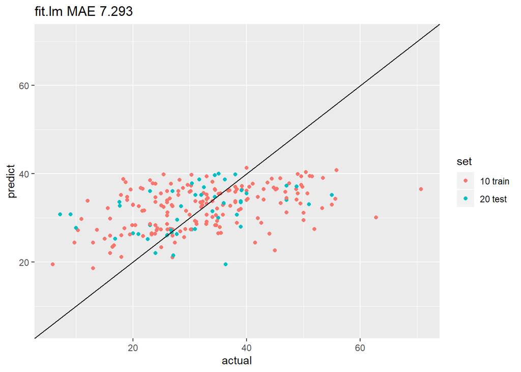

```r
show_res_all(fit.lm)
```

```r
summary(fit.lm)
```

```
##
## Call:
## lm(formula = form, data = df0)
##
## Residuals:
##     Min      1Q  Median      3Q     Max
## -23.591  -7.050  -0.382   5.889  34.155
##
## Coefficients:
##                         Estimate Std. Error t value Pr(>|t|)
## (Intercept)               2.2431     8.5813   0.261 0.794028
## TypeEPB                  -4.2453     2.4923  -1.703 0.089905 .
## TypeGripper               6.9755     2.0412   3.417 0.000753 ***
## TypeSlurry                4.5869     3.4503   1.329 0.185076
## TypeSS                    0.5159     5.1834   0.100 0.920812
## Diameter                  0.2221     0.3197   0.695 0.487928
## Length                    2.6361     0.9468   2.784 0.005829 **
## GeoConditionMetamorphic   2.5506     2.2892   1.114 0.266413
## GeoConditionSedimentary   4.7786     2.0318   2.352 0.019556 *
## GeoConditionSoft soil     6.9780     3.1701   2.201 0.028756 *
## ---
## Signif. codes:  0 '***' 0.001 '**' 0.01 '*' 0.05 '.' 0.1 ' ' 1
##
## Residual standard error: 10.46 on 221 degrees of freedom
## Multiple R-squared:  0.1879, Adjusted R-squared:  0.1549
## F-statistic: 5.683 on 9 and 221 DF,  p-value: 4.421e-07
```

# Robust Linear Regression

Linear regression but it removes outliers that may alter the equation too much, to provide a better and more accurate fit.

```r
fit.rlm <- MASS::rlm(form, data = df0)
pred.rlm <- predict(fit.rlm, newdata = test_df)
```

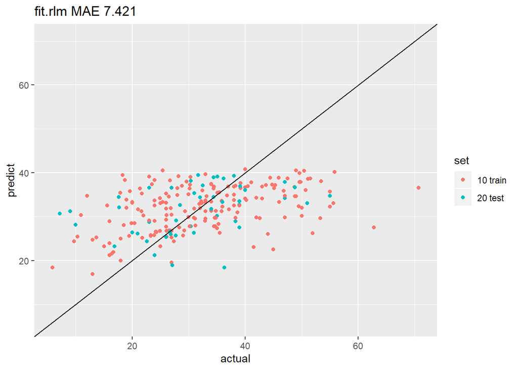

```r
show_res_all(fit.rlm)
```

```r
summary(fit.rlm)
```

```
##
## Call: rlm(formula = form, data = df0)
## Residuals:
##       Min        1Q    Median        3Q       Max
## -23.52223  -6.51945  -0.07581   6.44499  35.24715
##
## Coefficients:
##                         Value   Std. Error t value
## (Intercept)              1.2340  8.7811     0.1405
## TypeEPB                 -5.1128  2.5503    -2.0048
## TypeGripper              6.5880  2.0887     3.1541
## TypeSlurry               6.1494  3.5306     1.7417
## TypeSS                  -1.3107  5.3042    -0.2471
## Diameter                 0.0173  0.3271     0.0528
## Length                   2.8016  0.9688     2.8918
## GeoConditionMetamorphic  3.7347  2.3425     1.5943
## GeoConditionSedimentary  6.0369  2.0791     2.9036
## GeoConditionSoft soil    7.2609  3.2439     2.2383
##
## Residual standard error: 9.565 on 221 degrees of freedom
```

# Linear Model Selection

A model selection method, starting from the most complex model and removing factors successively to find the best fit

```r
step <- MASS::stepAIC(lm(final_mod,data=df0),k=2,direction='backward')
```

```
## Start:  AIC=1096.9
## Util ~ (Type + Diameter + Length + GeoCondition)^2
##
##                         Df Sum of Sq   RSS    AIC
## - Length:GeoCondition    3    177.90 20562 1092.9
## - Type:Length            4    588.14 20973 1095.5
## - Diameter:Length        1     96.60 20481 1096.0
## <none>                               20384 1096.9
## - Diameter:GeoCondition  3    783.31 21168 1099.6
## - Type:GeoCondition      6   1341.80 21726 1099.6
## - Type:Diameter          4   1624.11 22009 1106.6
##
## Step:  AIC=1092.91
## Util ~ Type + Diameter + Length + GeoCondition + Type:Diameter +
##     Type:Length + Type:GeoCondition + Diameter:Length + Diameter:GeoCondition
##
##                         Df Sum of Sq   RSS    AIC
## - Diameter:Length        1     24.69 20587 1091.2
## <none>                               20562 1092.9
## - Type:Length            4    754.72 21317 1093.2
## - Diameter:GeoCondition  3    787.25 21350 1095.6
## - Type:GeoCondition      6   1515.31 22078 1097.3
## - Type:Diameter          4   1494.78 22057 1101.1
##
## Step:  AIC=1091.19
## Util ~ Type + Diameter + Length + GeoCondition + Type:Diameter +
##     Type:Length + Type:GeoCondition + Diameter:GeoCondition
##
##                         Df Sum of Sq   RSS    AIC
## <none>                               20587 1091.2
## - Type:Length            4    786.15 21373 1091.8
## - Diameter:GeoCondition  3    800.69 21388 1094.0
## - Type:GeoCondition      6   1494.63 22082 1095.4
## - Type:Diameter          4   1501.49 22089 1099.5
```

모델이 바뀌어 나간 히스토리. 앞의 *-* 표시가 해당변수를 제거한 모델을 의미한다

```r
step$anova
```

```
## Stepwise Model Path
## Analysis of Deviance Table
##
## Initial Model:
## Util ~ (Type + Diameter + Length + GeoCondition)^2
##
## Final Model:
## Util ~ Type + Diameter + Length + GeoCondition + Type:Diameter +
##     Type:Length + Type:GeoCondition + Diameter:GeoCondition
##
##
##                    Step Df  Deviance Resid. Df Resid. Dev      AIC
## 1                                          200   20384.39 1096.905
## 2 - Length:GeoCondition  3 177.89733       203   20562.29 1092.912
## 3     - Diameter:Length  1  24.68862       204   20586.98 1091.189
```

그렇게 구한 최적의 모델

```r
form.lm.opt <- formula(step)
pred.lm.opt <- predict(step, newdata = test_df)
fit.lm1 <- step  # 최종적으로 가장 좋은 모델을 fit.ml1 에 넣는다
```

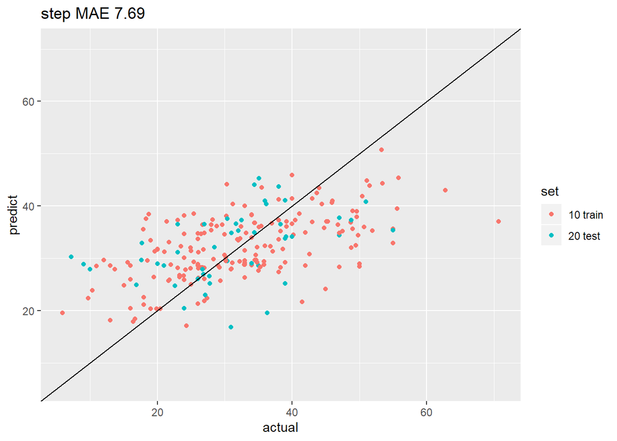

```r
show_res_all(step)
```

# Linear Regression by Cross validation

Modelling by splitting the data set into train and test data.

```r
fitControl <- trainControl(method = "repeatedcv", number = 10, repeats = 10)
fit.reg <- train(form.lm.opt, data = train_df, method = 'lm', trControl = fitControl)
pred.reg <- predict(fit.reg,newdata=test_df)
```

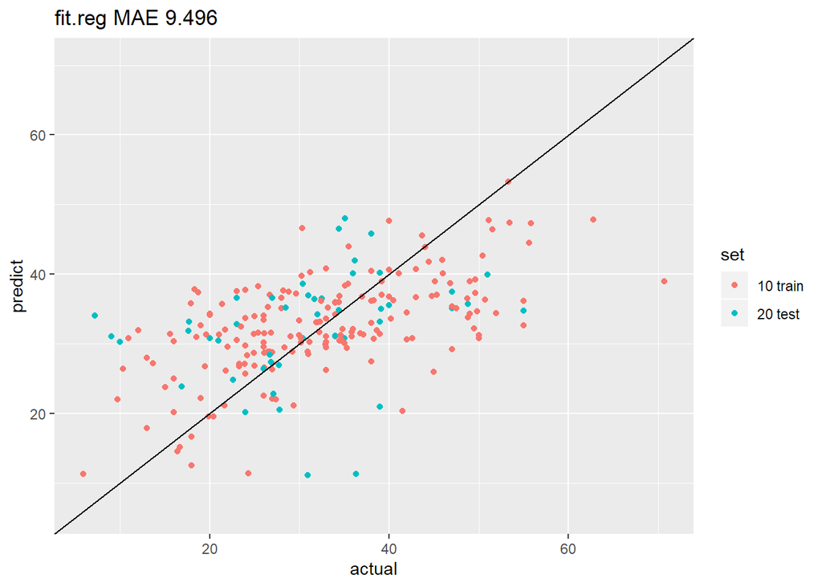

```r
show_res_all(fit.reg)
```

# MARS

Modeling based on set intervals.

Multiple Adaptive Regression Spline.

definition of hyper parameter grid to search.

```r
hyper_grid <- expand.grid(
  degree = 1:5,
  nprune = seq(2, 100, length.out = 20) %>% floor()
)
```

hyperparameter search .

```r
fit.mars <- train(
  x = subset(train_df[,predictors]),
  y = train_df[,response],
  method = "earth",
  metric = "MAE",
  trControl = trainControl(method = "cv", number = 10),
  tuneGrid = hyper_grid
)

pred.mars <- predict(fit.mars, newdata=test_df)
```

best model

```r
fit.mars$bestTune
```

```
##    nprune degree
## 22      7      2
```

result plot

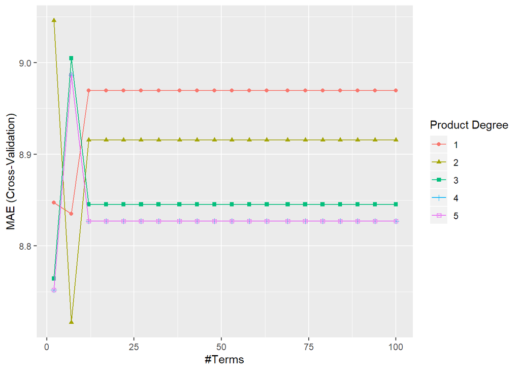

```r
ggplot(fit.mars)
```

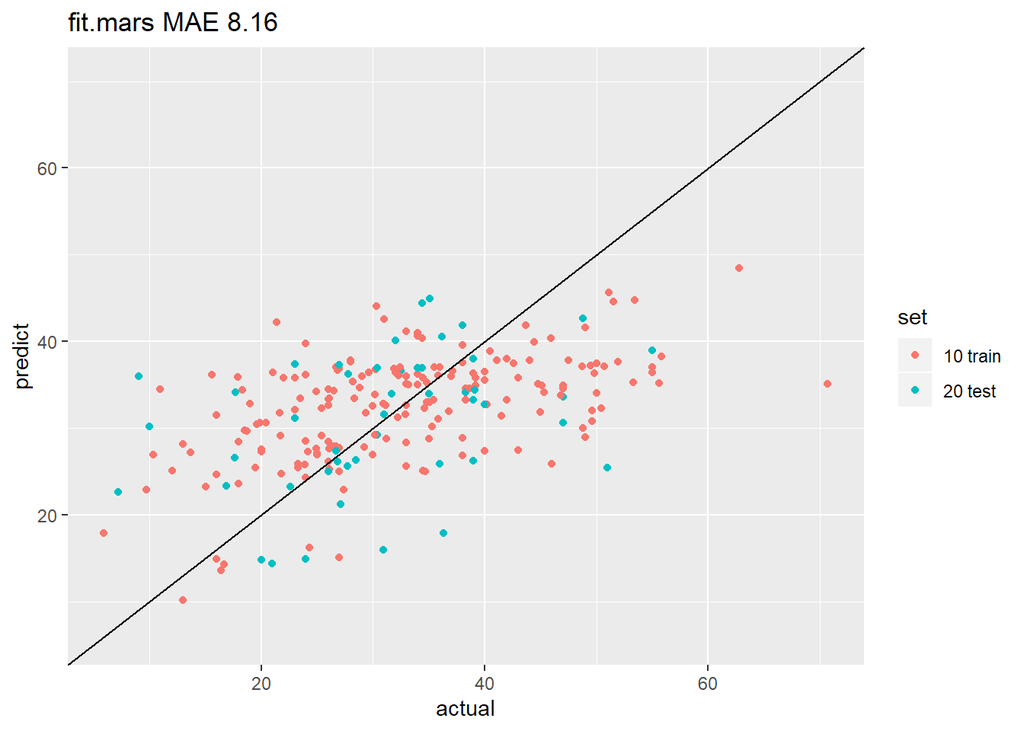

```r
show_res_all(fit.mars)
```

# decision tree

MOdelling based on branches of outcomes.

```r
library(rpart)
library(rpart.plot)

fitControl <- trainControl(method = "repeatedcv", number = 10, repeats = 10)
df.tree <- rpart( form, method="anova", data=df0)
```

```r
summary(df.tree) # tree Rule 을 표시
```

```
## Call:
## rpart(formula = form, data = df0, method = "anova")
##   n= 231
##
##            CP nsplit rel error    xerror       xstd
## 1  0.10609517      0 1.0000000 1.0084418 0.09215973
## 2  0.04865002      1 0.8939048 0.9596271 0.09420396
## 3  0.04655930      3 0.7966048 0.9767216 0.09386841
## 4  0.03593650      4 0.7500455 0.9715820 0.09828124
## 5  0.02783438      5 0.7141090 0.8996535 0.09215378
## 6  0.01971194      6 0.6862746 0.8541829 0.09080784
## 7  0.01635267      7 0.6665627 0.8896640 0.09252582
## 8  0.01392048      8 0.6502100 0.8981851 0.09278623
## 9  0.01181454      9 0.6362895 0.9334607 0.09280922
## 10 0.01000000     12 0.6008459 0.9322892 0.09301314
##
## Variable importance
##     Diameter       Length         Type GeoCondition
##           41           26           20           13
##
## Node number 1: 231 observations,    complexity param=0.1060952
##   mean=32.18433, MSE=128.8668
##   left son=2 (107 obs) right son=3 (124 obs)
##   Primary splits:
##       Type         splits as  LLRLR,        improve=0.10609520, (0 missing)
##       Length       < 7.797271 to the left,  improve=0.07679658, (0 missing)
##       Diameter     < 8.045    to the left,  improve=0.04614635, (0 missing)
##       GeoCondition splits as  LRRL,         improve=0.01029429, (0 missing)
##   Surrogate splits:
##       Diameter     < 6.535    to the right, agree=0.671, adj=0.290, (0 split)
##       Length       < 8.033875 to the left,  agree=0.654, adj=0.252, (0 split)
##       GeoCondition splits as  RRRL,         agree=0.632, adj=0.206, (0 split)
##
## Node number 2: 107 observations,    complexity param=0.04865002
##   mean=28.20383, MSE=108.4522
##   left son=4 (84 obs) right son=5 (23 obs)
##   Primary splits:
##       Diameter     < 8.035    to the left,  improve=0.10413230, (0 missing)
##       Type         splits as  RL-R-,        improve=0.05600097, (0 missing)
##       Length       < 8.553714 to the left,  improve=0.03742185, (0 missing)
```

[output cut: 127 more lines]

```
## Node number 61: 32 observations,    complexity param=0.01181454
##   mean=38.22188, MSE=97.81358
##   left son=122 (25 obs) right son=123 (7 obs)
##   Primary splits:
##       Length       < 9.260438 to the left,  improve=0.12119370, (0 missing)
##       Diameter     < 9.875    to the right, improve=0.09990321, (0 missing)
##       GeoCondition splits as  -LR-,         improve=0.01805289, (0 missing)
##   Surrogate splits:
##       Diameter < 4.41     to the right, agree=0.844, adj=0.286, (0 split)
##
## Node number 122: 25 observations
##   mean=36.4, MSE=73.216
##
## Node number 123: 7 observations
##   mean=44.72857, MSE=131.4706
```

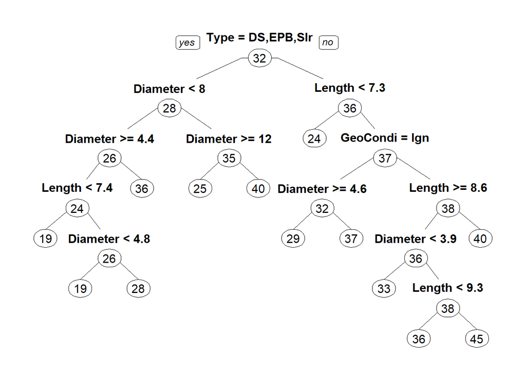

```r
prp(df.tree,type=1) # tree 자체를 그려주는 함수
```

# parameter search

```r
hyper_grid <- expand.grid(
  cp = seq(0.01,0.15,by=0.01) # 트리의 복잡도(complexity parameter)
)

fit.tree <- train( form, data=train_df, method = 'rpart', metric='MAE',
                   trControl = fitControl, tuneGrid = hyper_grid)
pred.tree <- predict(fit.tree, newdata = test_df)
```

```r
fit.tree
```

```
## CART
##
## 184 samples
##   4 predictor
##
## No pre-processing
## Resampling: Cross-Validated (10 fold, repeated 10 times)
## Summary of sample sizes: 166, 168, 165, 165, 165, 166, ...
## Resampling results across tuning parameters:
##
##   cp    RMSE      Rsquared    MAE
##   0.01  11.15366  0.17311848  8.901876
##   0.02  11.11874  0.16497903  8.945494
##   0.03  11.12675  0.15564414  8.979740
##   0.04  11.34767  0.11223934  9.224332
##   0.05  11.60760  0.08166957  9.518813
##   0.06  11.36151  0.10918402  9.244237
##   0.07  11.36570  0.10943224  9.246132
##   0.08  11.38511  0.10566837  9.262043
##   0.09  11.50280  0.08670031  9.354946
##   0.10  11.71914  0.04964934  9.510794
##   0.11  11.77609  0.03122358  9.547609
##   0.12  11.70770  0.02445612  9.510578
##   0.13  11.63058  0.04539681  9.420952
##   0.14  11.56340  0.06987448  9.377930
##   0.15  11.52181  0.03685028  9.350171
##
## MAE was used to select the optimal model using the smallest value.
## The final value used for the model was cp = 0.01.
```

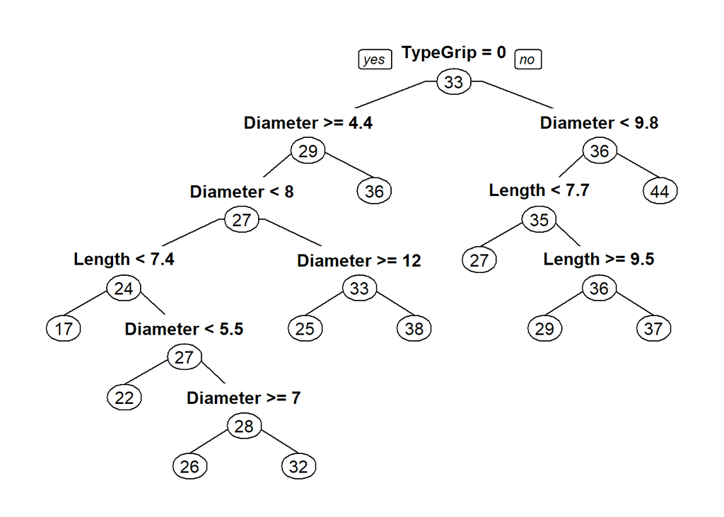

```r
prp(fit.tree$finalModel,type=1)
```

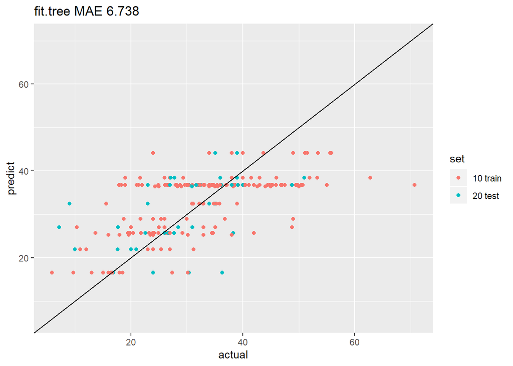

```r
show_res_all(fit.tree)
```